# Practice Activity 6.1

Import the Palmer Penguins dataset and print out the first few rows.

Suppose we want to predict `bill_depth_mm` using the other variables in the dataset.

Which variables would we need to **dummify**?

```python
import pandas as pd
import numpy as np
from palmerpenguins import load_penguins
from plotnine import ggplot, geom_point, aes, geom_line
from sklearn.linear_model import LinearRegression
from sklearn.preprocessing import PolynomialFeatures
```

```python
df = load_penguins()
df.head()
```

|  | species | island | bill_length_mm | bill_depth_mm | flipper_length_mm | body_mass_g | sex | year |
| --- | --- | --- | --- | --- | --- | --- | --- | --- |
| 0 | Adelie | Torgersen | 39.1 | 18.7 | 181.0 | 3750.0 | male | 2007 |
| 1 | Adelie | Torgersen | 39.5 | 17.4 | 186.0 | 3800.0 | female | 2007 |
| 2 | Adelie | Torgersen | 40.3 | 18.0 | 195.0 | 3250.0 | female | 2007 |
| 3 | Adelie | Torgersen | NaN | NaN | NaN | NaN | NaN | 2007 |
| 4 | Adelie | Torgersen | 36.7 | 19.3 | 193.0 | 3450.0 | female | 2007 |

We would need to dummify sex, Island type and species type.

```python
df = pd.get_dummies(df, columns=['species', 'island', 'sex'], drop_first=True)
df = df.dropna()
df.head()
```

|  | bill_length_mm | bill_depth_mm | flipper_length_mm | body_mass_g | year | species_Chinstrap | species_Gentoo | island_Dream | island_Torgersen | sex_male |
| --- | --- | --- | --- | --- | --- | --- | --- | --- | --- | --- |
| 0 | 39.1 | 18.7 | 181.0 | 3750.0 | 2007 | False | False | False | True | True |
| 1 | 39.5 | 17.4 | 186.0 | 3800.0 | 2007 | False | False | False | True | False |
| 2 | 40.3 | 18.0 | 195.0 | 3250.0 | 2007 | False | False | False | True | False |
| 4 | 36.7 | 19.3 | 193.0 | 3450.0 | 2007 | False | False | False | True | False |
| 5 | 39.3 | 20.6 | 190.0 | 3650.0 | 2007 | False | False | False | True | True |

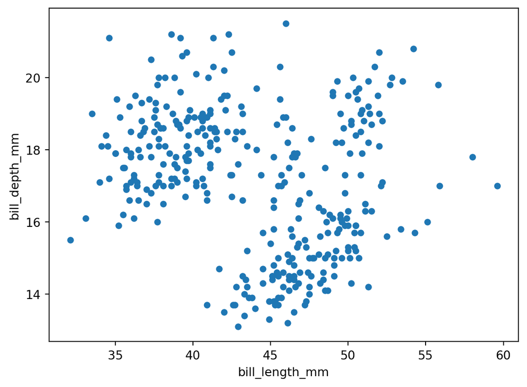

```python
df.plot.scatter(x="bill_length_mm", y="bill_depth_mm")
```

Let’s use `bill_length_mm` to predict `bill_depth_mm`. Prepare your data and fit the following models on the entire dataset:

- Simple linear regression (e.g. straight-line) model
- Quadratic (degree 2 polynomial) model
- Cubic (degree 3 polynomial) model
- Degree 10 polynomial model

Make predictions for each model and plot your fitted models on the scatterplot.